# visualization_lec2

## 우리 동네 인구 구조 시각화 하기

```python
import csv

f = open('age.csv')
data = csv.reader(f)

for row in data :
    print(row)
```

```python
print('신도림' in '서울특별시 구로구 신도림동(1153051000)')
print('1153' in '서울특별시 구로구 신도림동(1153051000)')
print('()' in '서울특별시 구로구 신도림동(1153051000)')
```

```
True
True
False
```

```python
# 우리동네(신도림) 데이터만 선택
import csv
f = open('age.csv')
data = csv.reader(f)

for row in data :
    if '신도림' in row[0] :
        print(row)
```

```
['서울특별시 구로구 신도림동(1153051000)', '37,268', '37,268', '326', '334', '406', '413', '389', '408', '417', '434', '411', '387', '420', '383', '354', '357', '340', '338', '349', '339', '407', '380', '390', '453', '424', '516', '451', '466', '448', '484', '471', '476', '558', '541', '579', '619', '638', '740…
```

```python
# 0~100세 까지의 인구수를 순서대로 저장
import csv
f = open('age.csv')
data = csv.reader(f)
result = []

for row in data :
    if '신도림' in row[0] :
        for i in row[3:] :  # 0세부터 끝(100세이상)까지 모든 연령에 대해 반속하기
            result.append(int(i))
print(result)
```

```
[326, 334, 406, 413, 389, 408, 417, 434, 411, 387, 420, 383, 354, 357, 340, 338, 349, 339, 407, 380, 390, 453, 424, 516, 451, 466, 448, 484, 471, 476, 558, 541, 579, 619, 638, 740, 756, 792, 745, 789, 671, 687, 700, 636, 726, 691, 657, 619, 649, 585, 579, 470, 522, 534, 563, 445, 511, 569, 572, 513,…
```

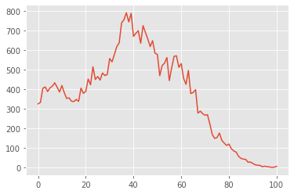

```python
# 시각화
import matplotlib.pyplot as plt
plt.style.use('ggplot')
plt.plot(result)
plt.show()
```

- 인구구조를 다양한 형태로 시각화

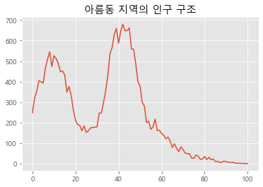

```python
import csv
f = open('age.csv')
data = csv.reader(f)
result = []
name = input('인구 구조가 알고 싶은 지역의 이름(읍면동 단위)을 입력해주세요 : ')
for row in data :
    if name in row[0] :
        for i in row[3:] :
            result.append(int(i))

import matplotlib.pyplot as plt
plt.style.use('ggplot')
plt.rc('font', family = 'Malgun Gothic')
plt.title(name +' 지역의 인구 구조')
plt.plot(result)
plt.show()
```

- 막대그래프 그리기

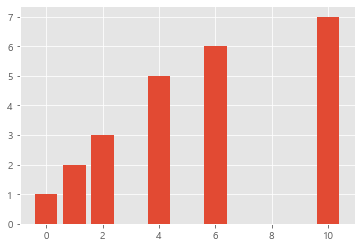

```python
# bar() 함수
import matplotlib.pyplot as plt
plt.bar([0,1,2,4,6,10], [1,2,3,5,6,7])
plt.show()
```

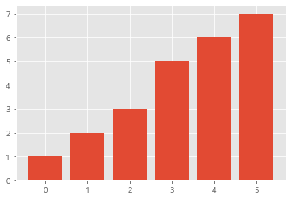

```python
import matplotlib.pyplot as plt
plt.bar(range(6), [1,2,3,5,6,7])
plt.show()
```

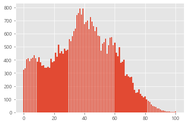

```python
# 우리동네(신도림) 인구구조
import csv
f = open('age.csv')
data = csv.reader(f)

result = []
for row in data :
    if '신도림' in row[0] :
        for i in row[3:] :
            result.append(int(i))

import matplotlib.pyplot as plt
plt.bar(range(101), result)
plt.show()
```

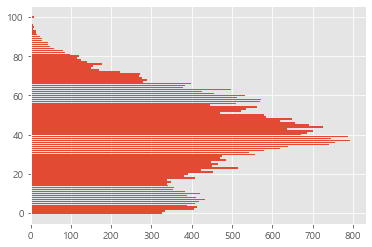

```python
# barh() 함수 : bar를 수평 방향으로 그리기
import csv
f = open('age.csv')
data = csv.reader(f)

result = []
for row in data :
    if '신도림' in row[0] :
        for i in row[3:] :
            result.append(int(i))

import matplotlib.pyplot as plt
#plt.figure(figsize = (10,5), dpi=300)
plt.barh(range(101), result)
plt.show()
```

### 남녀 성별이 포함된 데이터 활용

```python
import csv
f = open('gender.csv')
data = csv.reader(f)
m = []
f = []
for row in data :
    if '신도림' in row[0] :
        for i in range(0,101) :
            m.append(int(row[i+3]))
            f.append(int(row[-(i+1)]))
f.reverse()  # 리스트의 값을 역순으로 재배열 함수
```

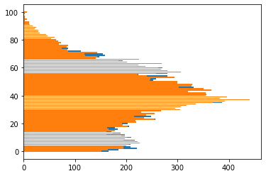

```python
import matplotlib.pyplot as plt
plt.barh(range(101), m)
plt.barh(range(101), f)
plt.show()
```

```python
# 남성 데이터를 음수로 바꾸어 남성 데이터를 왼쪽에 여성 데이터를 왼쪽에 둔다
import csv
f =open('gender.csv')
data = csv.reader(f)
m = []
f = []
for row in data :
    if'신도림'in row[0] :
        for i in row[3:104] :
            m.append(-int(i)) # 마이너스 부호를 넣어서 음수로 변경
        for i in row[106:] :

            f.append(int(i))
```

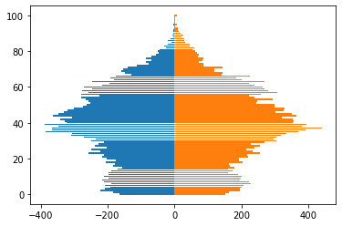

```python
import matplotlib.pyplot as plt
plt.barh(range(101), m)
plt.barh(range(101), f)
plt.show()
```

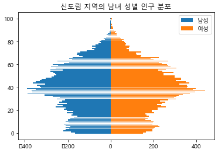

```python
# 범례추가
import matplotlib.pyplot as plt
plt.rc('font', family = 'Malgun Gothic')
plt.title('신도림 지역의 남녀 성별 인구 분포')
plt.barh(range(101), m, label = '남성')
plt.barh(range(101), f, label = '여성')
plt.legend()
plt.show()
```

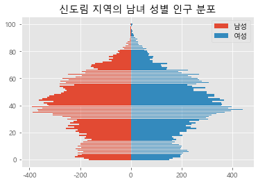

```python
# 한글, 마이너스 깨짐 처리
import matplotlib.pyplot as plt
plt.style.use('ggplot')
#plt.figure(figsize = (10,5), dpi=300)
plt.rc('font', family = 'Malgun Gothic')
plt.rcParams['axes.unicode_minus'] = False
plt.title('신도림 지역의 남녀 성별 인구 분포')
plt.barh(range(101), m, label = '남성')
plt.barh(range(101), f, label = '여성')
plt.legend()
plt.show()
```

- 우리동네 인구구조 항아리 모양으로 그래프 그리기

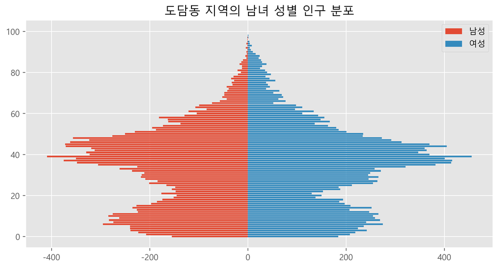

```python
import csv
f = open('gender.csv')
data = csv.reader(f)

m = []
f = []

name = input('찾고 싶은 지역의 이름을 알려주세요 : ')
for row in data :
    if name in row[0] :
        for i in row[3:104] :
            m.append(-int(i))
        for i in row[106:] :
            f.append(int(i))

import matplotlib.pyplot as plt
plt.style.use('ggplot')
plt.figure(figsize = (10,5), dpi=300)
plt.rc('font', family = 'Malgun Gothic')
plt.rcParams['axes.unicode_minus'] = False
plt.title(name + ' 지역의 남녀 성별 인구 분포')
plt.barh(range(101), m, label = '남성')
plt.barh(range(101), f, label = '여성')
plt.legend()
plt.show()
```

```python
print(len(m), len(f))
```

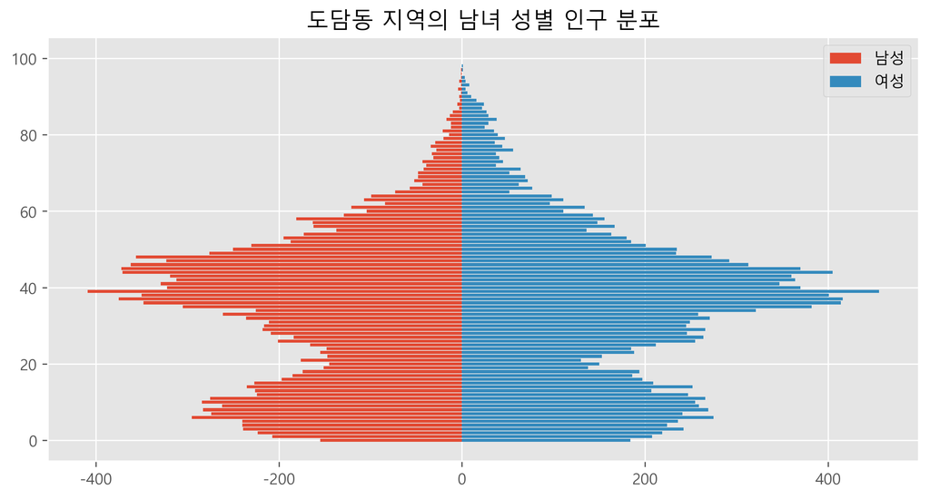

```python
# 제주특별자치도 검색시 에러 수정 : 두번째 for문에 break 문 넣기
import csv
f = open('gender.csv')
data = csv.reader(f)

m = []
f = []

name = input('찾고 싶은 지역의 이름을 알려주세요 : ')
for row in data :
    if name in row[0] :
        for i in row[3:104] :
            m.append(-int(i))
        for i in row[106:] :
            f.append(int(i))
        break
import matplotlib.pyplot as plt
plt.style.use('ggplot')
plt.figure(figsize = (10,5), dpi=300)
plt.rc('font', family = 'Malgun Gothic')
plt.rcParams['axes.unicode_minus'] = False
plt.title(name + ' 지역의 남녀 성별 인구 분포')
plt.barh(range(101), m, label = '남성')
plt.barh(range(101), f, label = '여성')
plt.legend()
plt.show()
```

### 우리동네 인구구조를 파이차트로 나타내기

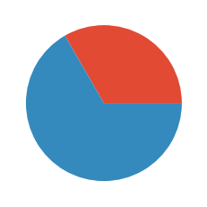

```python
# pie() 함수
import matplotlib.pyplot as plt
plt.pie([10,20])
plt.show()
```

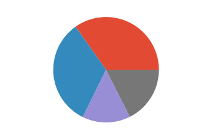

```python
# axis() 함수 : 동그란 원 그리기
import matplotlib.pyplot as plt
size = [2441, 2312, 1031, 1233]
plt.axis('equal')
plt.pie(size)
plt.show()
```

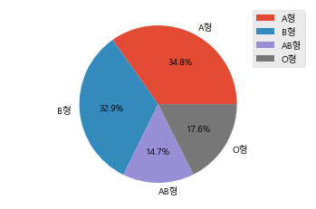

```python
# 비율 범례 표시하기
# autopct : auto percent 라는 의미, 어떤 형태로 값을 표시할 지 작성하면 각 항목의
#           비율을 자동으로 계산해서 표시.
# %.1f%% : 소수점 아래 첫번째 소수점까지 표현.
import matplotlib.pyplot as plt
plt.rc('font', family = 'Malgun Gothic')
size = [2441, 2312, 1031, 1233]
label = ['A형','B형','AB형', 'O형']
plt.axis('equal')
plt.pie(size, labels = label, autopct = '%.1f%%')   # 비율 및 범례 추가
plt.legend()
plt.show()
```

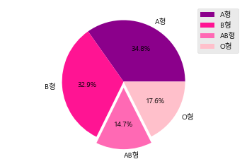

```python
# 색 및 돌출효과 정하기
# explode : 특정 혈액형의 비율이 돌출하는 효과
import matplotlib.pyplot as plt
plt.rc('font', family = 'Malgun Gothic')
size = [2441, 2312, 1031, 1233]
label = ['A형','B형','AB형', 'O형']
color = ['darkmagenta', 'deeppink', 'hotpink', 'pink']
plt.axis('equal')
plt.pie(size, labels = label, autopct = '%.1f%%', explode = (0,0,0.1,0), colors = color)
plt.legend()
plt.show()
```

- matplotlib 에서 지원하는 다양한 색 이름

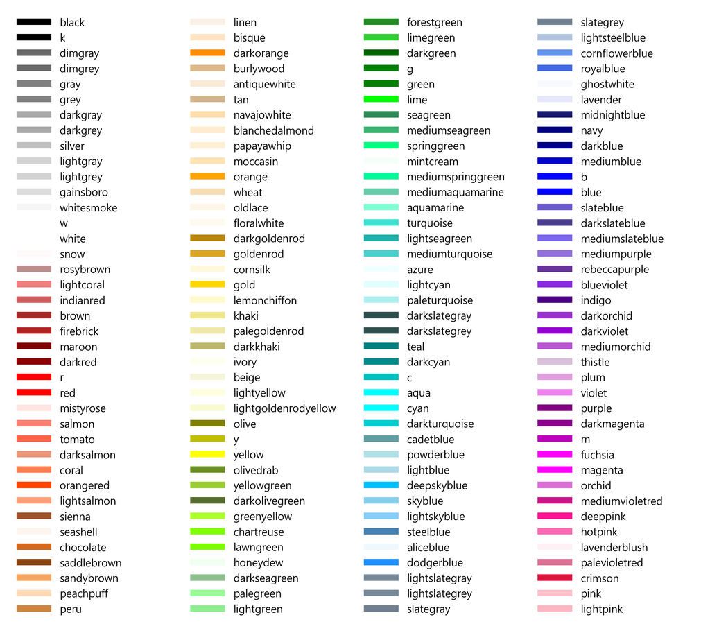

```python
import matplotlib.pyplot as plt
from matplotlib import colors as mcolors


colors = dict(mcolors.BASE_COLORS, **mcolors.CSS4_COLORS)

# Sort colors by hue, saturation, value and name.
by_hsv = sorted((tuple(mcolors.rgb_to_hsv(mcolors.to_rgba(color)[:3])), name)
                for name, color in colors.items())
sorted_names = [name for hsv, name in by_hsv]

n = len(sorted_names)
ncols = 4
nrows = n // ncols

fig, ax = plt.subplots(figsize=(9, 8), dpi = 300)

# Get height and width
X, Y = fig.get_dpi() * fig.get_size_inches()
h = Y / (nrows + 1)
w = X / ncols

for i, name in enumerate(sorted_names):
    row = i % nrows
    col = i // nrows
    y = Y - (row * h) - h

    xi_line = w * (col + 0.05)
    xf_line = w * (col + 0.25)
    xi_text = w * (col + 0.3)

    ax.text(xi_text, y, name, fontsize=(10),
            horizontalalignment='left',
            verticalalignment='center')

    ax.hlines(y + h * 0.1, xi_line, xf_line,
              color=colors[name], linewidth=(6))

ax.set_xlim(0, X)
ax.set_ylim(0, Y)
ax.set_axis_off()

fig.subplots_adjust(left=0, right=1,
                    top=1, bottom=0,
                    hspace=0, wspace=0)
plt.show()
```

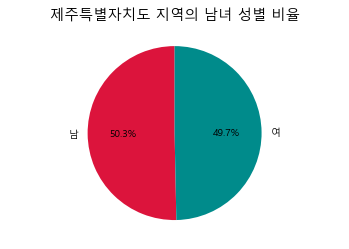

```python
import csv
f = open('gender.csv')
data = csv.reader(f)

size = []

name = input('찾고 싶은 지역의 이름을 알려주세요 : ')
for row in data :
    if name in row[0] :
        m = 0
        f = 0
        for i in range(101) :
            m += int(row[i+3])  # 남성 인구수를 누적해서 더하기
            f += int(row[i+106])  # 여성 인구수를 누적해서 더하기
        break
size.append(m)  # 남성 인구수를 size 리스트에 더하기
size.append(f)

import matplotlib.pyplot as plt
plt.rc('font', family ='Malgun Gothic')
color = ['crimson', 'darkcyan']
plt.axis('equal')
# startangle : 파이차트의 시작 각도 지정,
#              90으로 설정하면 반시계방향으로 90도 이동하여 정각 12시 위치에서 그래프가 시작.
plt.pie(size, labels = ['남','여'], autopct ='%.1f%%', colors = color, startangle =90)
plt.title(name + ' 지역의 남녀 성별 비율')
plt.show()
```

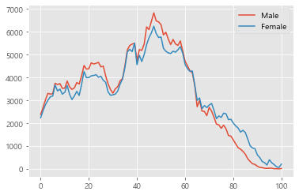

```python
# 꺽은선 그래프로 표현하기
import csv
f = open('gender.csv')
data = csv.reader(f)
m = []
f = []
name = input('궁금한 동네를 입력해주세요 : ')
for row in data :
    if name in row[0] :
        for i in range(3,104) :
            m.append(int(row[i]))
            f.append(int(row[i+103]))
        break
import matplotlib.pyplot as plt

plt.plot(m, label = 'Male')
plt.plot(f, label = 'Female')
plt.legend()
plt.show()
```

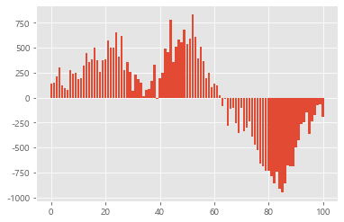

```python
# 막대 그래프로 표현하기
# 남성인구에서 여성인구를 뺀 값을 result에 추가
import csv
f = open('gender.csv')
data = csv.reader(f)
result = []
name = input('궁금한 동네를 입력해주세요 : ')
for row in data :
    if name in row[0] :
        for i in range(3,104) :
            result.append(int(row[i]) - int(row[i+103]))
        break
import matplotlib.pyplot as plt
plt.bar(range(101), result)
plt.show()
```

- 산점도로 표현하기

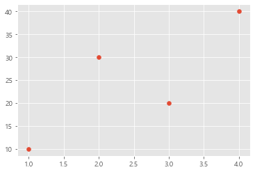

```python
import matplotlib.pyplot as plt
plt.style.use('ggplot')
plt.scatter([1,2,3,4], [10,30,20,40])
plt.show()
```

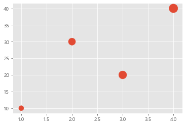

```python
import matplotlib.pyplot as plt
plt.style.use('ggplot')
plt.scatter([1,2,3,4], [10,30,20,40], s = [100,200,250,300])
plt.show()
```

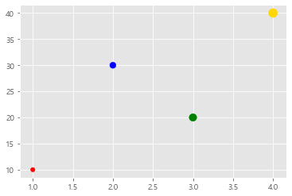

```python
import matplotlib.pyplot as plt
plt.style.use('ggplot')
plt.scatter([1,2,3,4], [10,30,20,40], s = [30,60,90,120], c = ['red','blue','green','gold'])
plt.show()
```

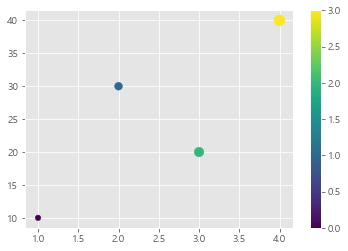

```python
import matplotlib.pyplot as plt
plt.style.use('ggplot')
plt.scatter([1,2,3,4], [10,30,20,40], s = [30,60,90,120], c = range(4))
plt.colorbar()
plt.show()
```

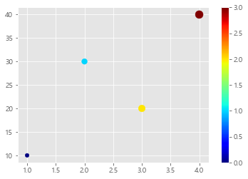

```python
import matplotlib.pyplot as plt
plt.style.use('ggplot')
plt.scatter([1,2,3,4], [10,30,20,40], s = [30,60,90,120], c =range(4), cmap='jet')
plt.colorbar()
plt.show()
```

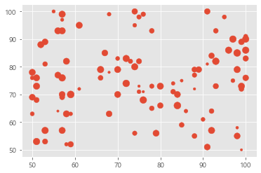

```python
import matplotlib.pyplot as plt
import random
x = []
y = []
size = []
for i in range(100) :
    x.append(random.randint(50,100))
    y.append(random.randint(50,100))
    size.append(random.randint(10,100))

plt.style.use('ggplot')
plt.scatter(x, y, s = size)
plt.show()
```

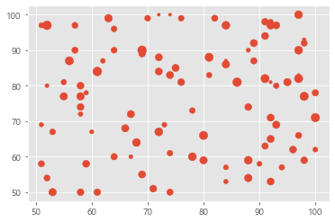

```python
import matplotlib.pyplot as plt
import random
x = []
y = []
size = []
for i in range(100):
    x.append(random.randint(50,100))
    y.append(random.randint(50,100))
    size.append(random.randint(10,100))
plt.style.use('ggplot')
plt.scatter(x, y, s = size)
plt.show()
```

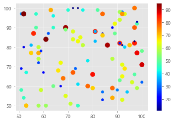

```python
plt.scatter(x, y, s = size, c = size, cmap='jet')
plt.colorbar()
plt.show()
```

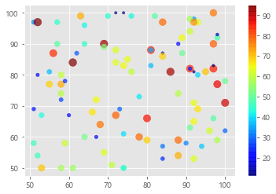

```python
plt.scatter(x, y, s = size, c = size, cmap='jet', alpha =0.7)
plt.colorbar()
plt.show()
```

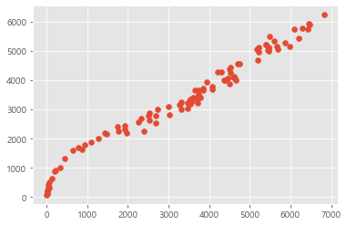

```python
import csv
f = open('gender.csv')
data = csv.reader(f)
m = []
f = []
name = input('궁금한 동네를 입력해주세요 : ')
for row in data :
    if name in row[0] :
        for i in range(3,104) :
            m.append(int(row[i]))
            f.append(int(row[i+103]))
        break
import matplotlib.pyplot as plt
plt.style.use('ggplot')
plt.scatter(m, f)
plt.show()
```

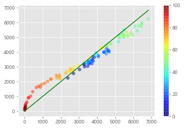

```python
import matplotlib.pyplot as plt
plt.style.use('ggplot')
plt.scatter(m, f, c =range(101), alpha=0.5, cmap='jet')
plt.colorbar()
plt.plot(range(max(m)),range(max(m)), 'g')
plt.show()
```

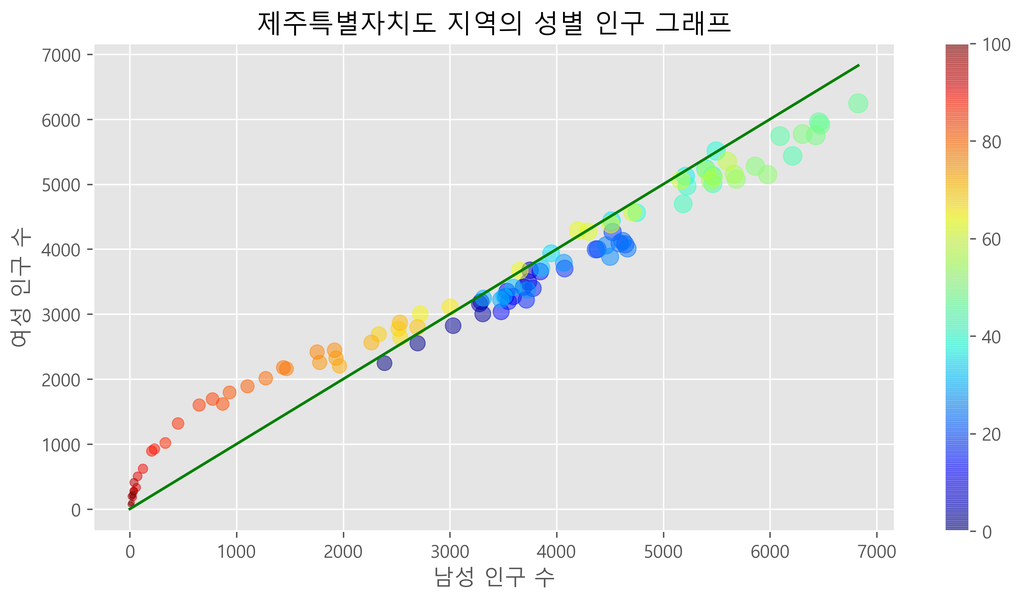

```python
import csv
import math
f = open('gender.csv')
data = csv.reader(f)
m = []
f = []
size = []
name = input('궁금한 동네를 입력해주세요 : ')
for row in data :
    if name in row[0] :
        for i in range(3,104) :
            m.append(int(row[i]))
            f.append(int(row[i+103]))
            size.append(math.sqrt(int(row[i]) + int(row[i+103])))
        break
import matplotlib.pyplot as plt
plt.style.use('ggplot')
plt.rc('font',family='Malgun Gothic')
plt.figure(figsize = (10,5), dpi=300)
plt.title(name+' 지역의 성별 인구 그래프')
plt.scatter(m, f, s = size, c = range(101), alpha=0.5, cmap='jet')
plt.colorbar()
plt.plot(range(max(m)),range(max(m)), 'g')
plt.xlabel('남성 인구 수')
plt.ylabel('여성 인구 수')
plt.show()
```

## 대중교통 데이터 시각화하기

### 데이터파일 내려받기

- 수도권 대중교통 데이터 제공 티머니 홈페이지( https://www.t-money.co.kr )
- 이용안내 > 대중교통 통계자료
- 최근 월간 교통카드 통계자료 게시글에서 엑셀 첨부 파일을 클릭해서 내려 받는다.
- 내려 받은 파일에는 '버스정류장별 이용현황', '지하철 노선별 역별 이용현황', '지하철 유무임별 이용현황', '지하철 시간대별 이용현황' 등 4개의 탭을 확인할 수 있다.

```python
import csv
f = open('subwayfee.csv')
data = csv.reader(f)

for row in data :
    print(row)

f.close()
```

```python
# 4번 열 문자열에서 정수로 바꾸기
import csv
f = open('subwayfee.csv')
data = csv.reader(f)
next(data)

for row in data :
    row[4] = int(row[4])
    print(row)

f.close()
```

```python
  # 4번 열부터 7번열까지 문자열을 정수로 바꾸기
import csv
f = open('subwayfee.csv')
data = csv.reader(f)
next(data)

for row in data :
    for i in range(4,8) :
        row[i] = int(row[i])
    print(row)

f.close()
```

### 유임 승차 비율이 가장 높은 역은 어디일까?

- rate = 유임승차인원 / 무임승차인원 (방법)
1. 데이터를 읽어온다.
2. 모든 역의 데이터를 바탕으로 각 역의 비율(rate)을 계산한다.
3. 비율이 가장 높은 역을 찾는다.
4. 비율이 가장 높은 역이 어디인지, 그 비율이 얼마인지 출력한다.

```python
# 1. 각 역의 비율 데이터를 저장할  rate라는 변수와 rate의 최댓값을 저장할 mx라는 변수를
#    0으로 초기화한다.
# 2. 유임 승차 인원 row[4]을 무임 승차 인원 row[6]으로 나눈 rate 값을 계산하고
#    rate 값이 최대일 띠를 찾는다.
```

```python
# 0나누는 경우가 발생할 경우엔 아래와 같이 ZeroDivisionError 발생
import csv
f = open('subwayfee.csv')
data = csv.reader(f)
next(data)
mx = 0
rate = 0
for row in data :
    for i in range(4,8) :
        row[i] = int(row[i])
    rate = row[4] / row[6]
    if rate > mx :
        mx = rate
print(mx)
f.close()
```

```
---------------------------------------------------------------------------
ZeroDivisionError                         Traceback (most recent call last)
<ipython-input-8-ce196d05df29> in <module>
      9     for i in range(4,8) :
     10         row[i] = int(row[i])
---> 11     rate = row[4] / row[6]
     12     if rate > mx :
     13         mx = rate

ZeroDivisionError: division by zero
```

```python
# row[6]인 역이 아래와 같이 있음을 알 수 있다.
import csv
f = open('subwayfee.csv')
data = csv.reader(f)
next(data)
mx = 0
rate = 0
for row in data :
    for i in range(4,8) :
        row[i] = int(row[i])
    if row[6] == 0 :
        print(row)

f.close()
```

```
['2019-01', '경원선', '1022', '창동', 19, 0, 0, 0]
['2019-01', '분당선', '1031', '복정', 25, 0, 0, 0]
['2019-01', '일산선', '1949', '지축', 2, 0, 0, 0]
['2019-01', '경의선', '1291', '서울역', 11, 0, 0, 0]
['2019-01', '경의선', '1293', '홍대입구', 2, 0, 0, 0]
['2019-01', '경의선', '1295', '김포공항', 10, 0, 0, 0]
['2019-01', '경의선', '1296', '계양', 7, 0, 0, 0]
['2019-01', '경의선', '1297', '검암', 5, 0, 0, 0]
```

```python
# ZeroDivisionError 방지를 위해 조건문 추가
# rate가 가장 높은 역이 어디인지, 얼마나 비율이 높은지 확인한다.
import csv
f = open('subwayfee.csv')
data = csv.reader(f)
next(data)
mx = 0
rate = 0
for row in data :
    for i in range(4,8) :
        row[i] = int(row[i])
    if row[6] != 0 :  # 무임승차인원 값이 0이 아니라면
        rate = row[4] / row[6]
        if rate > mx :  # rate이 mx 값보다 크다면
            mx = rate
            print(row, round(rate,2))

f.close()
```

```
['2019-01', '1호선', '0150', '서울역', 1516452, 1400464, 221180, 211764] 6.86
['2019-01', '1호선', '0152', '종각', 1240810, 1177643, 162410, 152062] 7.64
['2019-01', '2호선', '0201', '시청', 706097, 679503, 61058, 55387] 11.56
['2019-01', '2호선', '0202', '을지로입구', 1415414, 1414980, 120425, 111592] 11.75
['2019-01', '2호선', '0209', '한양대', 233785, 256079, 15380, 16652] 15.2
['2019-01', '2호선', '0222', '강남', 3153418, 3210437, 186486, 167666] 16.91
['2019-01', '2호선', '0239', '홍대입구', 2351935, 2507561, 114832, 111488] 20.48
['2019-01', '3호선', '0321', '충무로', 55, 0, 2, 0] 27.5
```

```python
# 충무로 역은 환승역이므로 유임하차 무임하차 값이 0이다.
# 그래서 전체 인원 중 유임 승차 인원을 구하는 방법으로 바꾸어 본다.
# (변경전) rate = 유임승차인원 / 무임승차인원
# (변경후) rate = 유임승차인원 / 전체(유임+무임)인원
# 유무임 승차인원을 합하여 100,000명 이상인 경우만 찾는 것으로 코드를 수정한다.

import csv
f = open('subwayfee.csv')
data = csv.reader(f)
next(data)
mx = 0
rate = 0
for row in data :
    for i in range(4,8) :
        row[i] = int(row[i])
    if row[6] !=0 and (row[4] + row[6]) >100000 :
        rate = row[4] / (row[4] + row[6])
        if rate > mx :
            mx = rate
            print(row, round(rate,2))

f.close()
```

```
['2019-01', '1호선', '0150', '서울역', 1516452, 1400464, 221180, 211764] 0.87
['2019-01', '1호선', '0152', '종각', 1240810, 1177643, 162410, 152062] 0.88
['2019-01', '2호선', '0201', '시청', 706097, 679503, 61058, 55387] 0.92
['2019-01', '2호선', '0202', '을지로입구', 1415414, 1414980, 120425, 111592] 0.92
['2019-01', '2호선', '0209', '한양대', 233785, 256079, 15380, 16652] 0.94
['2019-01', '2호선', '0222', '강남', 3153418, 3210437, 186486, 167666] 0.94
['2019-01', '2호선', '0239', '홍대입구', 2351935, 2507561, 114832, 111488] 0.95
```

```python
# rate > 0.94 추가
import csv
f = open('subwayfee.csv')
data = csv.reader(f)
next(data)
mx = 0
rate = 0
for row in data :
    for i in range(4,8) :
        row[i] = int(row[i])
    if row[6] !=0 and (row[4] + row[6]) >100000 :
        rate = row[4] / (row[4] + row[6])
        if rate > 0.94 :
            mx = rate
            print(row, round(rate,2))

f.close()
```

```
['2019-01', '2호선', '0222', '강남', 3153418, 3210437, 186486, 167666] 0.94
['2019-01', '2호선', '0239', '홍대입구', 2351935, 2507561, 114832, 111488] 0.95
['2019-01', '경부선', '1001', '서울역', 178223, 29980, 10325, 1612] 0.95
['2019-01', '9호선', '4125', '신논현', 965930, 995451, 57013, 54557] 0.94
['2019-01', '공항철도 1호선', '4203', '홍대입구', 336328, 335507, 17545, 17112] 0.95
['2019-01', '공항철도 1호선', '4206', '마곡나루', 133488, 119389, 8060, 8192] 0.94
['2019-01', '공항철도 1호선', '4207', '김포공항', 300654, 196229, 18640, 14332] 0.94
['2019-01', '공항철도 1호선', '4210', '청라국제도시', 174320, 164483, 9921, 9676] 0.95
```

- 유임승차비율이 가장 높은 역 찾기

```python
import csv
f = open('subwayfee.csv')
data = csv.reader(f)
next(data)
mx = 0
rate = 0
for row in data :
    for i in range(4,8) :
        row[i] = int(row[i])
    if row[6] !=0 and (row[4] + row[6]) >100000 :
        rate = row[4] / (row[4] + row[6])
        if rate > mx :
            mx = rate
            mx_station = row[3] + ' ' + row[1]

print(mx_station, round(mx * 100,2))
f.close()
```

```
홍대입구 2호선 95.34
```

- 유무임 승하차 인원이 가장 많은 역은?

```python
import csv
f = open('subwayfee.csv')
data = csv.reader(f)
next(data)
mx = [0] * 4
mx_station = [''] * 4

for row in data :  # 모든 역에 대해 반복
    for i in range(4,8) :  # 4번 부터 7번 인덱스를 반복하며 정수로 바꾸어 준다.
        row[i] = int(row[i])
        if row[i] > mx[i-4] :  # 해당 역이 지금가지 저장된 최댓값보다 클 경우
            mx[i-4] = row[i]   # mx와 mx_station을 갱신한다.
            mx_station[i-4] = row[3] + ' ' + row[1]

for i in range(4) :
    print(mx_station[i], mx[i])

f.close()
```

```
강남 2호선 3153418
강남 2호선 3210437
종로3가 1호선 387062
제기동 1호선 400607
```

- 모든 역의 유무임 승하차 비율 파이차트로 표현하기

```python
import csv
f = open('subwayfee.csv')
data = csv.reader(f)
next(data)
mx = [0] * 4
mx_station = [''] * 4
label = ['유임승차','유임하차','무임승차','무임하차']
for row in data :
    for i in range(4,8) :
        row[i] = int(row[i])
        if row[i] > mx[i-4] :
            mx[i-4] = row[i]
            mx_station[i-4] = row[3] + ' ' + row[1]
for i in range(4) :
    print(label[i] + ' : ' + mx_station[i], mx[i])
```

```
유임승차 : 강남 2호선 3153418
유임하차 : 강남 2호선 3210437
무임승차 : 종로3가 1호선 387062
무임하차 : 제기동 1호선 400607
```

```python
 import csv
import matplotlib.pyplot as plt
f = open('subwayfee.csv')
data = csv.reader(f)
next(data)
label = ['유임승차','유임하차','무임승차','무임하차']
for row in data :
    for i in range(4,8) :
        row[i] = int(row[i])
    #plt.figure(dpi = 300)
    plt.pie(row[4:8])
    plt.axis('equal')
    plt.show()

f.close()
```

```python
import csv
import matplotlib.pyplot as plt
f = open('subwayfee.csv')
data = csv.reader(f)
next(data)
label = ['유임승차','유임하차','무임승차','무임하차']
c = ['#14CCC0', '#389993', '#FF1C6A', '#CC14AF']
plt.rc('font', family = 'Malgun Gothic')
for row in data :
    for i in range(4,8) :
        row[i] = int(row[i])
    plt.figure(dpi = 300)
    plt.title(row[3] + ' ' + row[1])
    plt.pie(row[4:8], labels = label, colors = c, autopct = '%1.f%%')
    plt.axis('equal')
    plt.show()
```

```python
# 그래프 이미지 저장하기
import csv
import matplotlib.pyplot as plt
f = open('subwayfee.csv')
data = csv.reader(f)
next(data)
label = ['유임승차','유임하차','무임승차','무임하차']
c = ['#14CCC0', '#389993', '#FF1C6A', '#CC14AF']
plt.rc('font', family = 'Malgun Gothic')
for row in data :
    for i in range(4,8) :
        row[i] = int(row[i])
    plt.figure(dpi = 300)
    plt.title(row[3] + ' ' + row[1])
    plt.pie(row[4:8], labels = label, colors = c, autopct = '%1.f%%')
    plt.axis('equal')
    plt.savefig(row[3] + ' ' + row[1] + '.png')
    plt.show()

f.close()
```